# Tidy Tuesday 11-12

Megan Smith

2024-11-12

# Load Libraries

```r
library(tidyverse)
library(here)
library(naniar)
library(DT)
library(grid)
library(shadowtext)
library(ggtext)
```

# Reading in Tidy Tuesday Data

```r
tuesdata <- tidytuesdayR::tt_load('2024-11-12')

countries <- tuesdata$countries
country_subdivisions <- tuesdata$country_subdivisions
former_countries <- tuesdata$former_countries
```

# Exploring Datasets

```r
glimpse(countries)
glimpse(country_subdivisions)
glimpse(former_countries)
```

After exploring data I have decieded to see how many subdivisions are in each country

```r
con_sub<- country_subdivisions %>% # just need this data set and countries
  select(code, name, alpha_2) %>% #selecting what I need
  na.omit()#getting rid of NAs

con<- countries %>%
  select(alpha_2,con_name= name) %>% #changing name so when I merge I dont lose data
  na.omit() #getting rid of NAs
```

Next I will use the naniar package just to confirm there is no missing data

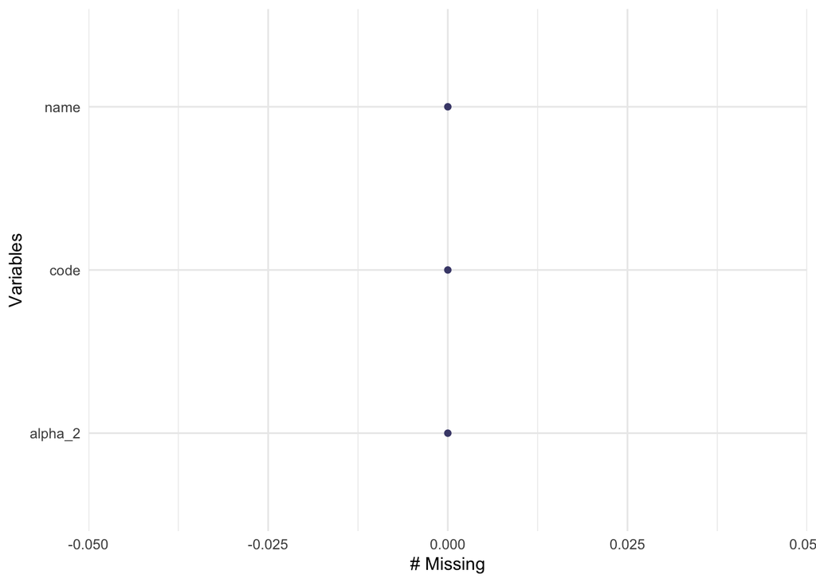

```r
gg_miss_var(con_sub)
```

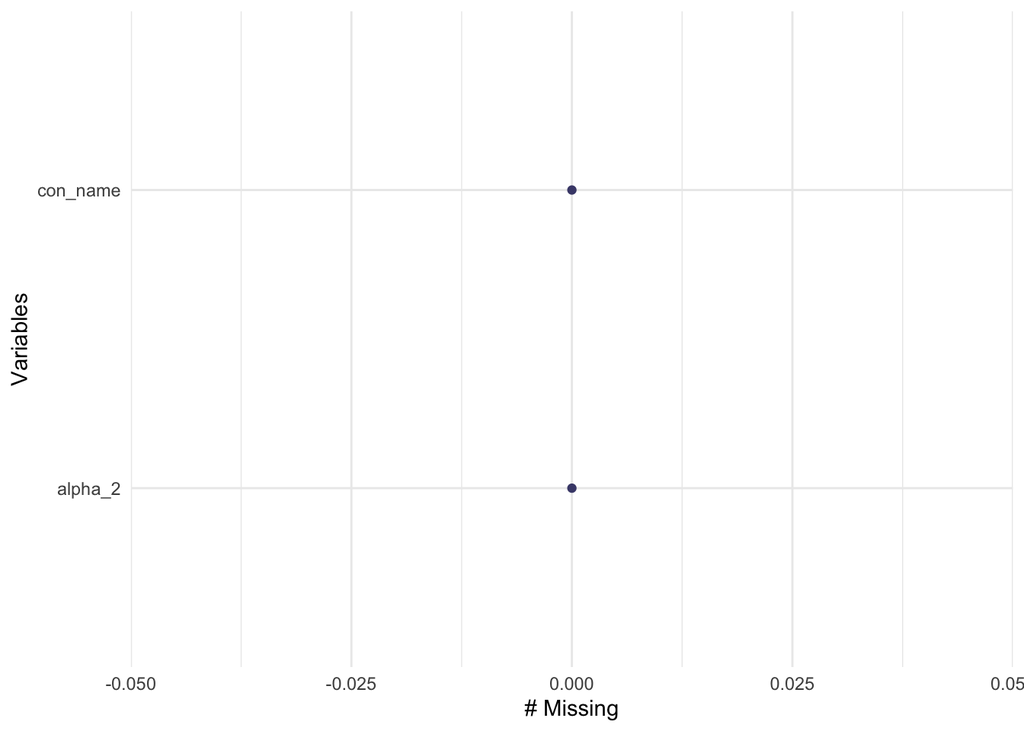

```r
gg_miss_var(con)
```

# Joining Data Sets

```r
con_joined<-left_join(con_sub,con)
glimpse(con_joined)
```

# Something New

Here I wanted to make a searchable table that showed country name, country code and the total number of subdivisions in each. This table allows you to customise how many rows you want to show and how you want it to be sorted, but you can also change how you see the data using the table as well. To create I used the package [“DT”](https://rstudio.github.io/DT/) This was beneficial to see since I decieded to only chose the top 15 countries with the most subdivisions for my plot.

```r
con_joined %>%
  count(alpha_2, con_name, sort = TRUE) %>%
  datatable(rownames = FALSE,# false so I could change column names
            colnames = c("Country Code", "Country Name", "Total"), # changing column names
            options = list(pageLength = 10, # how many rows per page
            order = list(list(2, 'desc'))),# keeping it in highest to lowest
            caption= "Total Subdivisions Per Country")
```

| Country Code | Country Name | Total |
| --- | --- | --- |
| GB | United Kingdom | 221 |
| SI | Slovenia | 212 |
| UG | Uganda | 139 |
| IT | Italy | 126 |
| FR | France | 124 |
| PH | Philippines | 99 |
| EE | Estonia | 94 |
| CZ | Czechia | 90 |
| MA | Morocco | 87 |
| RU | Russian Federation | 83 |

[output cut: 189 more lines]

# Filtering for plotting

I now want to look at the top 15 countries with the highest subdivisions, so I will create a column for the totals of each country name, then I will create a subset of that data for the top 15.

```r
con_joined <- con_joined %>%
  group_by(con_name) %>% #grouping so it can total
  mutate(tot = n()) %>% # creating a new column with totals
  ungroup() # ungrouping
# now filtering out top 15
top_15 <- con_joined %>%
  arrange(desc(tot)) %>% # making it in desending order
  distinct(con_name, .keep_all = TRUE) %>% # keeping the first occurance of the first "con_name"
  slice_head(n = 15) %>% # selecting the top 15
  mutate(y = seq(n()) * 0.9, # these next two lines are so that I could use geom_shadow text where I needed con_name to be a factor so I could use the levels to plot
    con_name = factor(con_name, levels = con_name))
```

# Creating figure

For this plot I found a way to way a [bar chart that mimics the look of The Economist](https://r-graph-gallery.com/web-horizontal-barplot-with-labels-the-economist.html) - Using geom_shadowtext is also something new for me. It allowed me to put text on the columns. I can see myself using this in the future for sure. - I personally liked how the code was broken up and how it was explained becuase I was able to build up the figure.

First creating a color list

```r
BLUE <- "#076fa2"
RED <- "#E3120B"
BLACK <- "#202020"
GREY <- "grey50"
```

Basic level of figure

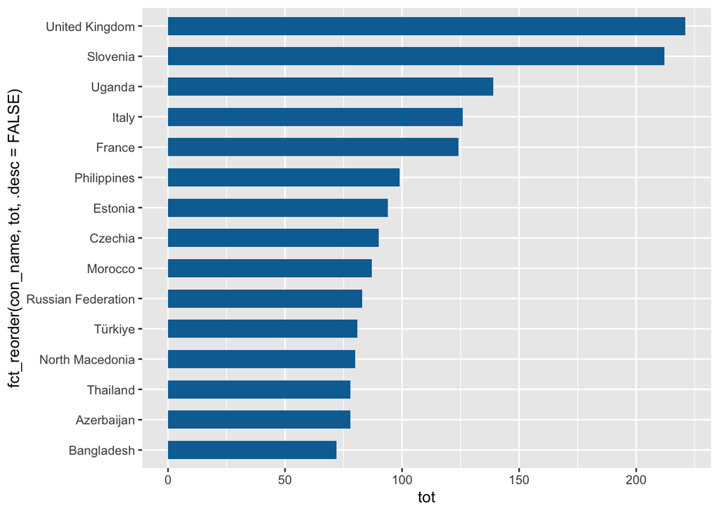

```r
plt <- ggplot(top_15) +
  geom_col(aes(tot, fct_reorder(con_name, tot, .desc = FALSE)), fill = BLUE, width = 0.6) # keeping in descending order
plt
```

Now adding the next layer

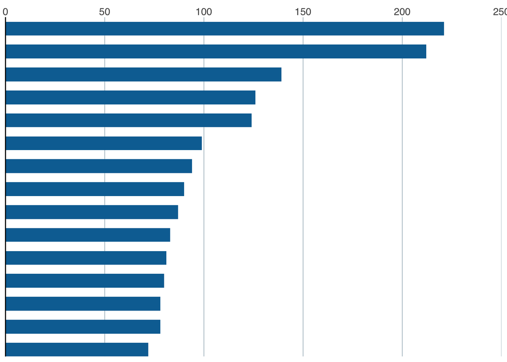

```r
plt <- plt + # adding on to above layer
  scale_x_continuous(limits = c(0, 250), # creating bounds for x axis
                     breaks = seq(0, 250, by = 50), # telling where axis ticks are
                     expand = c(0, 0),
                     position = "top") + # keeping legend on the top
  scale_y_discrete(expand = expansion(add = c(0, 0.5))) +
  theme(panel.background = element_rect(fill = "white"), #background to white
        panel.grid.major.x = element_line(color = "#A8BAC4", size = 0.3), # color and width of gridlines
        axis.ticks.length = unit(0, "mm"), # remocing tick marks
        axis.title = element_blank(), # removing title and will add later
        axis.line.y.left = element_line(color = "black"), # only left y axis will have line
        axis.text.y = element_blank(), #removing labels
        axis.text.x = element_text(family = "sans" , size = 10)) #customizing x axis font and size

plt
```

Now adding in text on top of columns using shadowtext

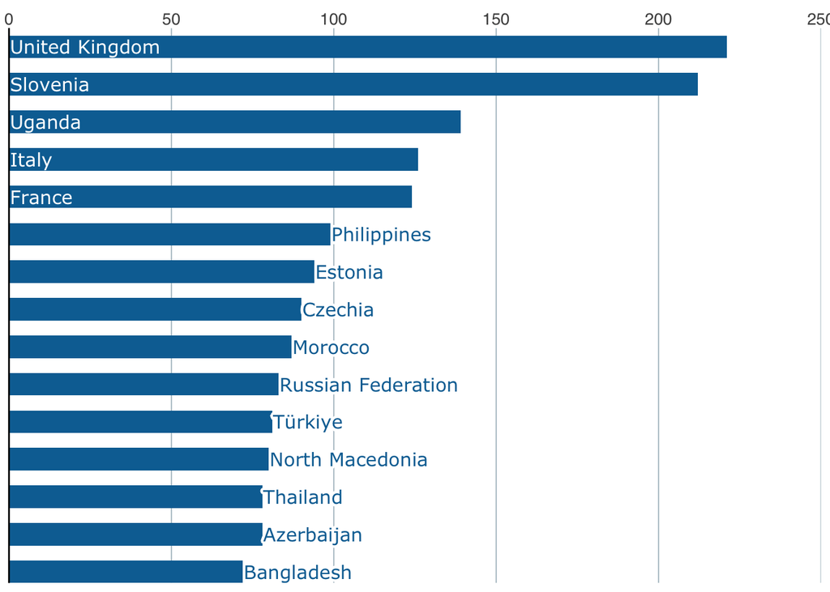

```r
plt <- plt +
  geom_shadowtext(data = subset(top_15, tot < 100), # selecting all top 15 with more than 100 subdivisions to have name ontop of column
    aes(tot, y = con_name, label = con_name), # choosing what data it will use
    hjust = 0,
    nudge_x = 0.3,# moving a little
    colour = BLUE, # outline color
    bg.colour = "white",# background color
    bg.r = 0.2,
    family = "Verdana", #font
    size = 4) + # font size
  geom_text(data = subset(top_15, tot >= 100),# now this will put the name next to column with subdivisions less than 100
    aes(0, y = con_name, label = con_name),
    hjust = 0,
    nudge_x = 0.3,# to move it a little
    colour = "white",# outline color
    family = "Verdana",# font
    size = 4) # font size
plt
```

Now is adding a title and lines to make it look like The Economist

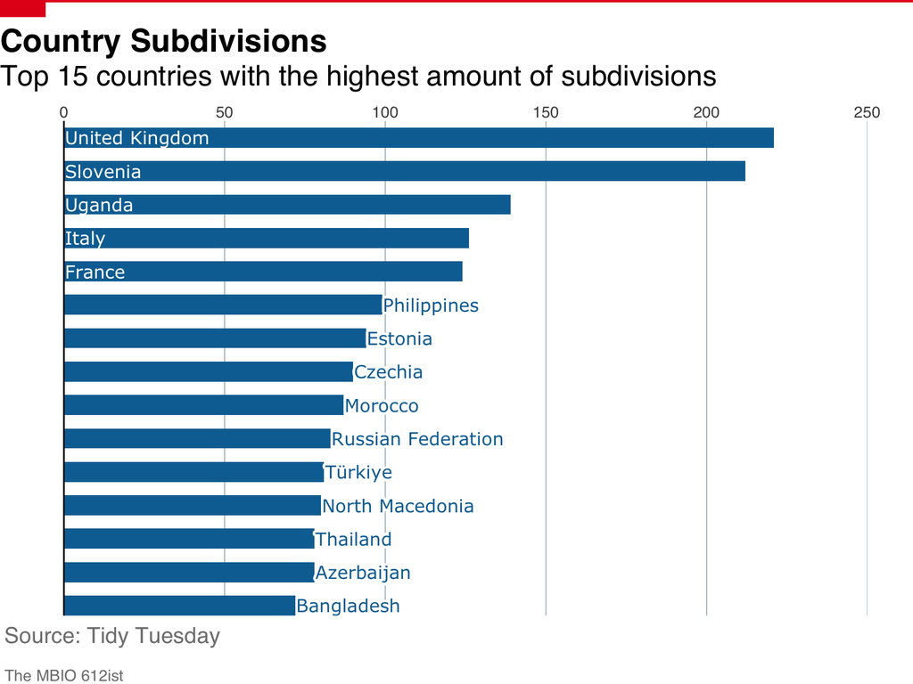

```r
plt <- plt +
  labs(title = NULL, subtitle = NULL) +
  theme(plot.margin = margin(0.15, 0.05, 0.1, 0.07, "npc")) # giving extra space for title

plt

grid.text("Country Subdivisions", 0, 0.925, # title and where it will be
  just = c("left", "bottom"), # telling where it wants it
  gp = gpar(fontsize = 20,# font size
            fontface = "bold",# bolded
            fontfamily = "sans"))# choosing sans

grid.text("Top 15 countries with the highest amount of subdivisions", 0, 0.875, # second title and where it will be
  just = c("left", "bottom"),# telling where
  gp = gpar(fontsize = 18,# size
            fontfamily = "sans")) #font

grid.lines(x = c(0, 1), #making the red line on top, telling where it will be
           y = 1, #telling where to start
           gp = gpar(col = "#e5001c", lwd = 4)) # color and width of line

grid.rect(x = 0,  y = 1, # this creates the red rectangle and begining of red line
          width = 0.05, #telling how wide
          height = 0.025, # how high
          just = c("left", "top"),# where to be
          gp = gpar(fill = "#e5001c", lwd = 0)) # what color

grid.text("Source: Tidy Tuesday", # giving source info
          x = 0.005, y = 0.06, #telling where to be
          just = c("left", "bottom"), #telling where to be
          gp = gpar(col = GREY, #what color
                    fontsize = 14, # font size
                    fontfamily = "sans")) # font

grid.text("The MBIO 612ist", # this would be where it says "The Economist"
  x = 0.005, y = 0.005, # telling where
  just = c("left", "bottom"), #telling where
  gp = gpar(col = GREY, # color
            fontsize = 10, #font size
            fontfamily = "sans")) #font
```